# 沟通心理学 Communication Psychology

林闻正|Lin Wenzheng

## 教师介绍

姓名：林闻正

单位：江西师范大学心理学院

邮箱：teach@linwz.com

## 课程材料 Course Materials

Beebe, S., Beebe, S., & Ivy, D. (2021). Communication: Principles for a lifetime, 8th edition. Pearson.

[figure not shown]

- - 学习通
    - 请假
    - 课件
    - 考核

[figure not shown]

## 出勤与纪律要求 Attendance and requirement

- 随机点名
- 每学期两次的请假（无需理由）
  - 学习通讨论区
  - 请假人数限制：每堂课不超过选课人数的10%
  - 时间限制：上课前24小时**前**
- 不满足上述条件的任何请假均需提供正式请假条；紧急情况通过邮件联系我
- 手机不上桌
- 不迟到
- 积极参与课堂讨论

## 考核 Evaluation

- 考试 20%：全客观题；开卷；第13周左右；随堂
- 出勤 10%
- 平时表现 10%
- 面试沟通挑战 60%
  - 小组任务 20%： 计算公式 20*教师评价系数*组员互评系数*组长系数加成
    - 职位招聘考核设计 （pdf）
    - 会议议程 （pdf with template）
    - 会议记录（pdf with template）
  - 面试表现 20%：学习通互评
  - 简历 20% （pdf）

## 提问环节

- 课后有其他问题可以通过邮件联系或等下节课提问

## 为什么要学习沟通 （1）

- 你为什么选择这门课？
  - 002195 言语交际与人际沟通
  - 002902 辩论与口才
  - 002185 当众讲话艺术
  - 002186 恋爱心理学
  - 002914 社交礼仪实务
  - 002208 中外礼仪（公选）
  - 002167 师生沟通技巧
  - 002013 言语交际学
  - 002076 人际交往心理学
  - 002161 演讲与口才（公选）
  - 002164 表达的艺术
  - 002946 人际沟通艺术（公选）

## 为什么要学习沟通 （2）

- “人类“沟通
  - 一项研究的估计发现超过60%的学生不能在口头上清楚地给人指路
  - 另一个美国全国性的研究发现成人的倾听准确性只有25%
  - 绝大多数的美国成年人害怕在公众场合发言

## 为什么要学习沟通 （3）

- 提升你的就业能力
  - 任何职业中你最本质的工作都与沟通有关
    - 交谈、倾听、认同、阅读以及写作
  - 基于一个针对雇员的问卷调查，下面列出了他们认为在大学毕业后获得雇佣的影响因素的重要性排序：
    - 1. 口头沟通
    - 2. 在多元群体中的团队合作技巧
    - 3. 书面沟通
    - 4. 批判性思维与分析性推理
    - 5. 复杂问题解决能力
    - 6. 信息素养
    - 7. 创新与创造能力
    - 8. 业务技能
    - 9. 定量推理能力

## 为什么要学习沟通 （4）

- 改善你的人际关系
  - 一段高质量的关系的核心在于高质量的沟通
  - 对于没结婚的人来说，建立友谊寻找爱情是生活中最主要的幸福感和满意度的来源
  - 大多数19-24岁的人报告他们有过5-6次的浪漫关系，并且真心相爱过1-2次
  - 维琴尼亚·萨提亚（Virginia Satir）：家庭增益治疗

## 为什么要学习沟通 （5）

- 改善你的健康
  - 缺少或失去亲密关系可以导致不健康的状态甚至死亡
  - 丧偶或者离异的病人跟婚姻中的人相比常有更多的医疗问题，比如心脏病、癌症、肺炎以及糖尿病

## 沟通的定义

- 从最广义的角度来看，**沟通（communications）**是对于信息的行动过程。
- **人类沟通**，*理解世界并将其通过言语和非言语消息创造意义来与他人分享的过程。*
  - 理解意义
  - 分享意义
  - 创造意义
- 消息：我们赋予意义的书面的、口头的或者非言语的元素

[figure not shown]

## 沟通的特征

- 沟通是不可避免的
- 沟通是不可逆的
- 沟通是复杂的
  - 沟通学者迪恩·巴恩伦德（Dean Barnlund）提出，无论何时我们在与另一个人进行沟通时，事实上至少涉及六个“人”：

    1. 你认为你是谁

    2. 你认为另一个人是谁

    3. 你认为另一个人认为你是谁

    4. 另一个人认为他或她自己是谁

    5. 另一个人认为你是谁

    6. 另一个人认为你认为他或她是谁。
  - 斯堪的纳维亚的沟通学者奥斯莫·维奥（Osmo Wiio）用格言的方式指出了沟通中存在的挑战：
    - 1.如果沟通可能失败，它就会失败。
    - 2.如果消息能用不同的方式理解，它就会以造成伤害最大的方式被理解。
    - 3.总会有人比你自己更能解读你想在消息中表达什么。
    - 4.沟通越多，沟通想要成功就越困难。
- 沟通强调内容和关系
  - 内容维度指的是新的信息、想法或者发言者希望表达的建议的行为
  - 关系维度通常来说更不明显；它提供了说话者情绪、态度和权力和控制的线索给其他人
- 沟通是由规则主导的

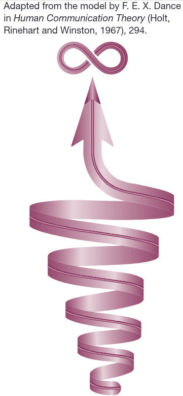

## 沟通模型

- **沟通模型**视觉化地展现了在沟通过程中包含的主要元素

## 作为行动的沟通：消息传递

- 沟通发生在消息发出和接受时

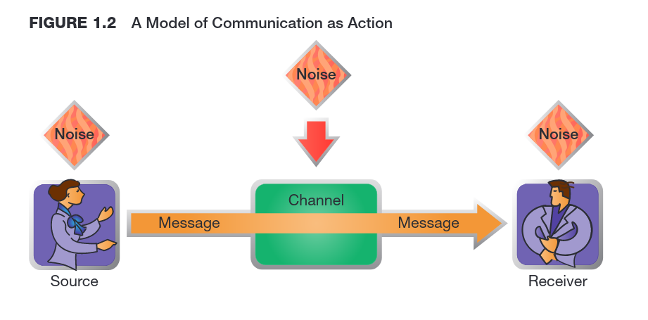

- 来源: 想法或情绪的发起者
  - **编码**是将思想、情感和想法转译为一种代码的过程。
  - **解码**是编码的逆过程。
- **接收者**是对信号进行解码和尝试对来源编码的信息进行意义提取的人
- **消息**是沟通中我们赋予意义的书面的、言语的或非言语的元素
- **渠道**是指消息在发出者和接收者沟通的过程中通过的一些路径
- **噪音**就是干扰,让消息不能被理解并达成设想的效果

## 作为互动的沟通：消息交换

- 为了把真实沟通中的复杂性考虑进来，早期的行动模型逐渐开始加入更强调互动性和妥协的元素

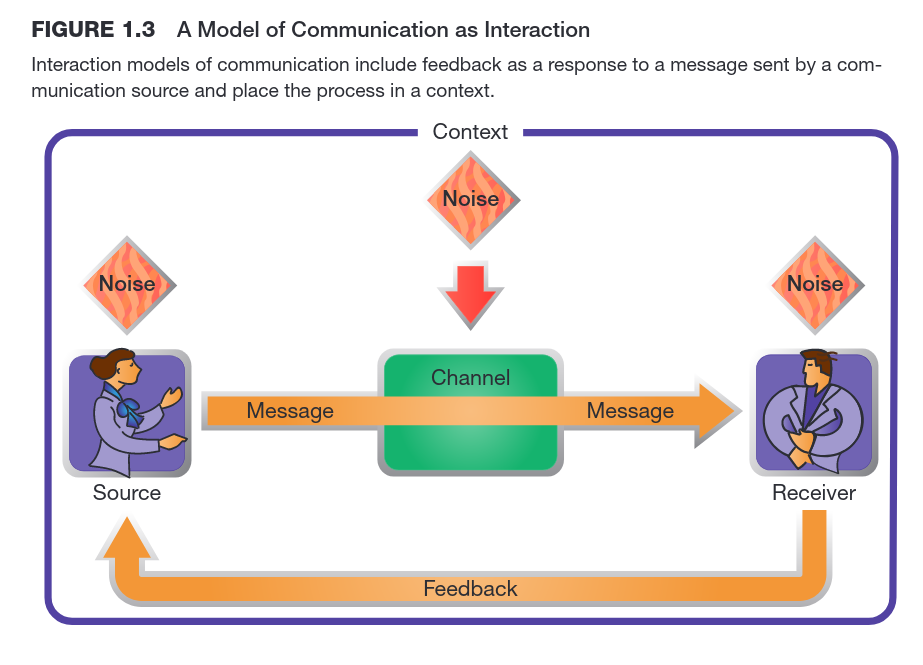

- **反馈**是对一个消息的回应
- 情境:可以影响沟通本质的物理、历史、心理以及文化环境
  - *物理情境*指沟通发生的地点
  - *历史情境*指过去对当前及未来沟通的影响
  - *心理情境*指一个人思想和情绪状态对沟通的影响
  - *文化情境*包括我们对群体和社会的认同，也包括我们知觉到的权力和地位水平

## 作为交易的沟通：消息创造

- 来源和接收者*同时*发出和接受着消息

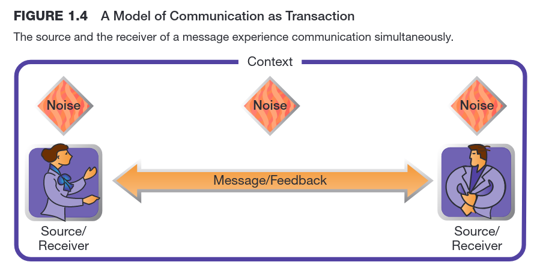

- C.S.刘易斯: “你能看到和听到的东西很大程度上取决于你所持的立场是什么，也取决于你是个什么样的人。”
- 在一次沟通交易中，消息的意义是由参与通信过程的个体*共同*创造的

## 沟通的竞争力

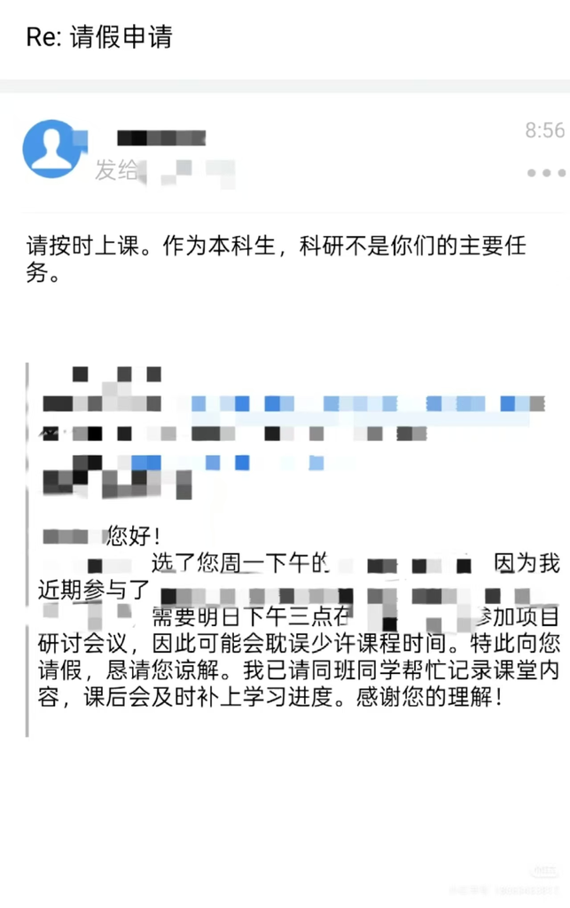

- 消息应该以沟通者预期的方式被理解
- 消息应该达成沟通者期望的效果
  - *公开讲话*的目的是传达信息，说服他人，或者娱乐大众
  - 在*小型群体*里，我们的目标通常是解决问题、做出决策
  - 在我们的*人际互动*中，我们的目标可能是建立信任、拉近关系、享受他人的陪伴
- 消息应该是符合道德伦理的
  - 《传播伦理与普世价值观》
    - 真理的价值
    - 对他人尊严的尊重
    - 无辜的人不会受到伤害的期望
  - *存在普世价值吗？

## 21世纪的沟通

- 有媒介的沟通
  - 微信、qq
  - 探探
  - 小红书、抖音、知乎
  - ……
- 大众沟通

## 即时沟通

- 同步沟通
  - 手机通话、微信?
- 异步沟通
  - 电子邮件、微博、微信?、小红书

## 频繁的沟通

- 生活在北美的人每天在网上花费2小时以上，而南美和非洲人则在网上花费3小时以上的时间
- 多任务处理变得越来越常见
- 在COVID-19疫情期间，在校园封闭、线上教学迅速取代面对面课程

## 满足我们需求的沟通

- 研究结果发现，人们在互联网上的使用越多，他们与人面对面的互动就越少
- 广泛社交媒体使用与孤独感之间的正相关关系
- 后续研究表明，对于那些本来就容易害羞或内向的人，互联网使用可能存在与孤独感或社交孤立感之间的联系

## 舒适的沟通

- 即时沟通vs异步沟通
- 不诚实的沟通

[figure not shown]

## 沟通的背景

## 人际沟通

- 人际沟通是一种特殊形式的人类沟通
  - 我们与另一个人同一时间进行交流并试图相互影响时，通常这是为了关系管理
- 非人际沟通发生在我们将人们视为目标，或只针对其角色而非将其作为有独立人格的个体时

## 群体沟通

- 我们大部分的工作和娱乐活动都是在群体中进行的
- **小群体沟通**：在三到十五个人之间进行的言语和非言语的信息交流，他们共享一个共同的目标，归属于同一团体，并相互对彼此产生影响
- 技术与虚拟群体

## 演讲沟通

- 演讲沟通是指演讲者向一群人发表讲话，以提供信息、改变态度或娱乐享受
- 亚里士多德《修辞学》
  - 他将**修辞学**定义为在特定情境中发现可用的说服手段的过程
  - 本质上，说服是使用符号来影响他人的过程

## 组织与健康沟通

- **组织沟通**是研究人类在组织内进行沟通的学科
- **健康沟通**主要研究能影响我们健康的沟通的作用和重要性
  - 医护人员（如医生、医生助理和护士）与患者之间的互动
  - 如何最好地设计宣传活动，以鼓励健康的习惯

## 终身的沟通原则

- 原则一：觉察你同你自己和他人的沟通
  - 有效的沟通者在沟通时是有意识的或”在场的”
  - **自我沟通**指的是发生在你自己内部的沟通，包括你的思想、情绪以及对自己和他人的感知
- 原则二：有效地使用和解读言语消息
  - **语言**包含着符号和一套规则（语法），使人们能够相互理解
  - 有效的沟通者能准确地编码和解码消息
- 原则三：有效地使用和解读非言语消息
  - 非言语信息可以比单纯的词语更有力地传达有力的思想或情感
- 原则四：对他人周全的倾听和回应
  - 与他人进行有效沟通听众也承担着相当大的责任
- 原则五：适当地调整给他人的消息

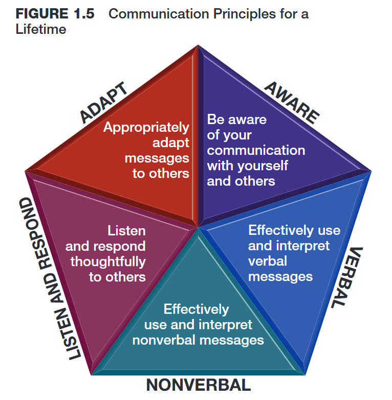